# Pressão do Twitter

Este relatório tem como objetivo comparar duas métricas para a pressão do Twitter no Painel Parlamentria. Os dados utilizados são tweets sobre proposições monitoradas pelo Painel no período de 31/12/2018 a 26/04/2021.

## Cálculo da pressão

A pressão foi calcula da seguinte forma:

1. Adicionando escala logarítmica ao engajamento;
2. Normalizando o número de usuários diferentes e o engajamento se baseando no maior valor obtido durante a semana (considerando todas as proposições);
3. Calculando a pressão utilizando a fórmula **`pressao = 0.5 * num_usuarios + 0.5 * log2(engajamento)`**.
4. Também utilizamos como métrica a **média móvel da pressão** nas últimas 3 semanas.

## PL 3267/2019

Esta proposição foi tweetada por parlamentares e/ou influenciadores por 42 semanas. Abaixo podemos ver sua pressão calculada considerando os dois scores explicados anteriormente.

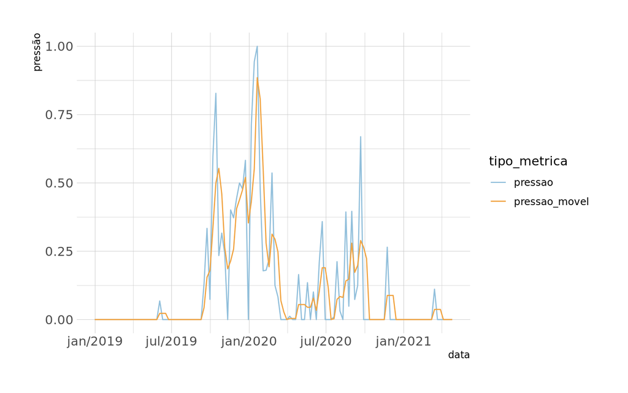

## PL 2630/2020

Esta proposição possui o maior engajamento (replies + likes + retweets). Na semana do dia 29/06/2020, 52 usuários diferentes tweetaram sobre este projeto de lei e juntos tiveram cerca de 313.1K engajamentos.

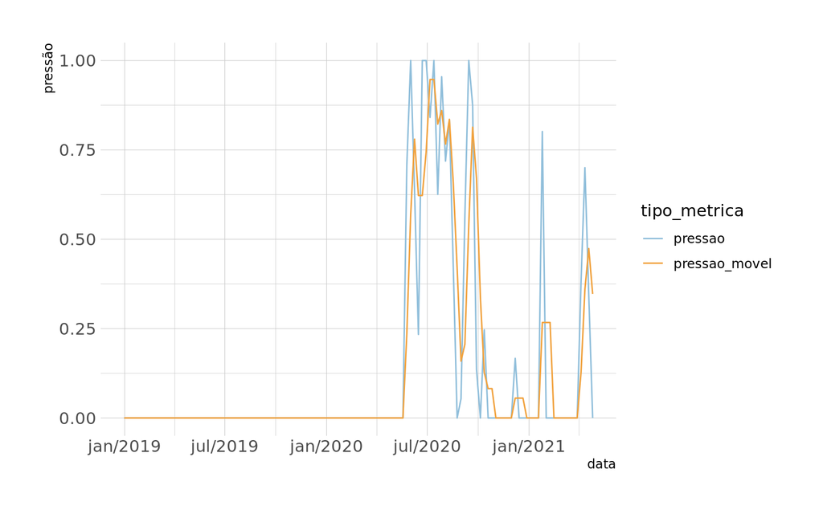

## MPV 870/2019

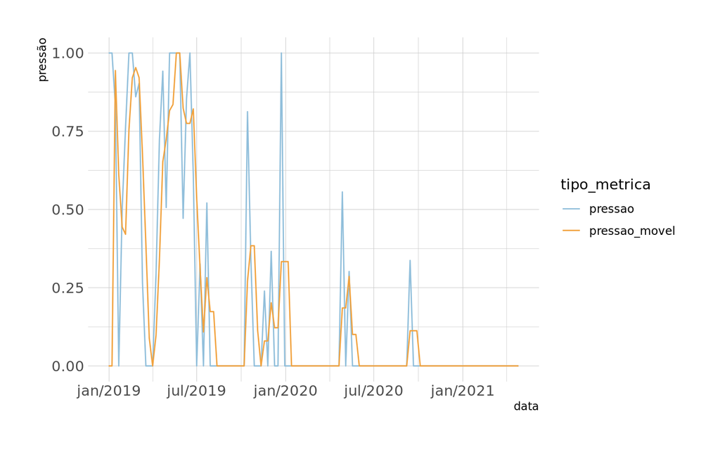

## Proposições que possuem pressão por mais tempo

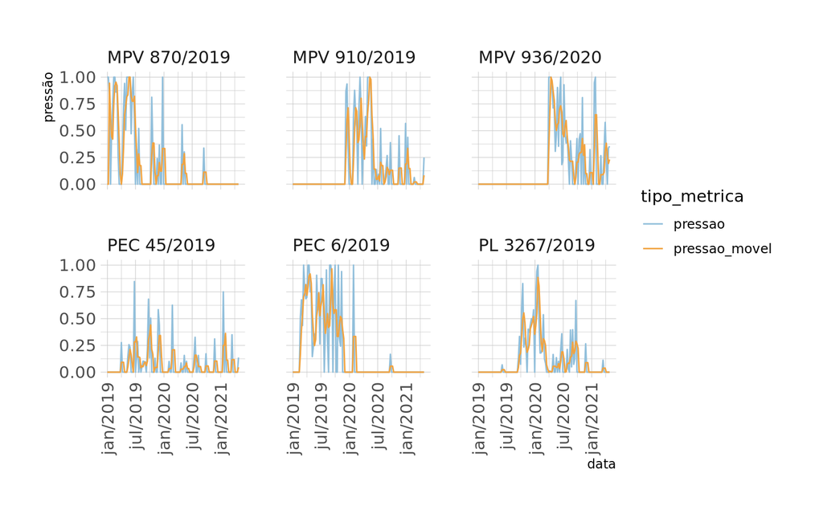

As proposições falam dos seguintes assuntos:

- MPV 870/2019: Reorganização dos órgãos da presidência, dos ministérios e suas atribuições;
- MPV 910/2019: Regularização fundiária e grilagem;
- MPV 936/2020: Programa Emergencial de Manutenção do Emprego e Renda;
- PEC 45/2019: Reforma Tributária;
- PEC 6/2019: Reforma da Previdência;
- PL 3267/2019: Código de Trânsito.

## Tabela com os dados

|  | data | sigla | norm_user_count | norm_log_sum_interactions | pressao | pressao_movel |
| --- | --- | --- | --- | --- | --- | --- |
| 1 | 2018-12-31 | MPV 868/2018 | 0 | 0 | 0 | 0 |
| 2 | 2018-12-31 | MPV 870/2019 | 1 | 1 | 1 | 0 |
| 3 | 2018-12-31 | MPV 881/2019 | 0 | 0 | 0 | 0 |
| 4 | 2018-12-31 | MPV 910/2019 | 0 | 0 | 0 | 0 |
| 5 | 2018-12-31 | MPV 936/2020 | 0 | 0 | 0 | 0 |
| 6 | 2018-12-31 | MPV 944/2020 | 0 | 0 | 0 | 0 |
| 7 | 2018-12-31 | PEC 110/2019 | 0 | 0 | 0 | 0 |
| 8 | 2018-12-31 | PEC 15/2015 | 0 | 0 | 0 | 0 |
| 9 | 2018-12-31 | PEC 32/2020 | 0 | 0 | 0 | 0 |
| 10 | 2018-12-31 | PEC 33/2012 | 0 | 0 | 0 | 0 |

[output cut: 2430 more lines]